# TS simulations - ZooScatR

Sven Gastauer

10/09/2020

```r
#tidyverse for cleaner code
library(tidyr)
library(dplyr)
library(purrr)
#apply with progress
library(pbapply)

#plotting
library(ggplot2)

#special libraries
library(ZooScatR)

#pdf stuff
library(kableExtra)
library(knitr)

#exporting results
library(feather)

#define if simulations should be multi-threadded. THis will run the simulations in parallel using with # cores available -1
runParallel = TRUE
if (runParallel == TRUE){
  library(foreach)
  library(doParallel)

  registerDoParallel(parallel::detectCores()-1)
}
#force running a new simulation, even if an RDS file with simualtions is available
force=TRUE
#set working dir
setwd('C:\\Users\\mbd\\phd\\ZooScatStuff\\')
```

## Model definition

Let’s start by loading some standard values for the model:

```r
#number of simulations
nsim = 1000
#location of the standard parameter file contained within the package
fname <- paste0(system.file(package="ZooScatR"),"/extdata/configs/config_0.dat")
# read the parameters file
para = ZooScatR::read_para(fname)
#set the soundspeed in the surrounding sea water
misc <- list(cw=1480)
#let's set the start and end frequencies
f0=80 #will bepara$simu$var0
f1=600 #will be para$simu$var1
#number of output frequencies
nf=801 #will be para$simu$n
```

For the parameter distributions a gamma, normal or uniform dsitribution were used.  
For gamma distributions a density function with a shape $s$ and a rate $a$ was defined as:

$$f_{\Gamma}(x)= \frac{1}{s^a \Gamma(a) x^{a-1} e^{-\frac{x}{s}}}$$
where $\Gamma(a)$ is defined as [@milne-thomson_handbook_1972]:
$$\Gamma(a)=\int_0^\infty{t^{a-1}e^{-t} dt}$$

Normal distributions were computed with standard deviation $\sigma$ and mean $\mu$ with a density given by [@johnson_continuous_1995]:
$$f_N(x)=\frac{1}{\sqrt{2\pi}\sigma e^{-{\frac{(x-\mu)^2}{2\sigma^2}}}}$$
A summary of the settings is defined in table 1. The acoustically-dominant species that are considered weakly scatterers are the ones described in the table below. the table also contains all their parameters space settings.

```r
pm = data.frame(species=c('Copepod','Krill','Chaetognaths','KrillBig', 'Amphipod', 'Limacina', 'FishLarvae'),
  L_dist=c('gamma', 'gamma','log normal', 'log normal','gamma', 'gamma', 'gamma'),
  L_shape =  c(7,    15,     2,     0.85,10,  6.8,   5.0),
  L_rate =   c(4,     4,   0.4,     0.46, 2,  4.8,   1.3),
  L_a_dist = c('normal'),
  L_a_mean = c(2.7,10.5, 17.15, 10.5,     3,  2.5,   8.5),
  L_a_sd =   c(0.1, 0.1,     1.5,  0.1,     0.5,  0.05,   1),
  g_dist = 'uniform',
  g_min = c(1.025,1.015, 1.029, 1.037,1.056, 1.729, 0.997),
  g_max = c(1.027,1.017, 1.031, 1.039,1.057, 1.731, 0.999),
  h_dist = 'uniform',
  h_min = c(1.026,1.018, 1.029, 1.021,1.025, 1.729, 1.10),
  h_max = c(1.028,1.020, 1.031, 1.031,1.027, 1.731, 1.12),
  theta_dist='uniform',
  theta_mean = c(90, 20,     0,    20,    0,    20,     0),
  theta_sd =   c(5, 5,    5,    5,   5,    5,    5),
  rho_l =    c(   3,  3,     3,     3,    13,     3,     3),
  taper =    c(  4,   5,     2,     5,    15,     2,     2)
)
```

| species | L_dist | L_shape | L_rate | L_a_dist | L_a_mean | L_a_sd |
| --- | --- | --- | --- | --- | --- | --- |
| Copepod | gamma | 7.00 | 4.00 | normal | 2.70 | 0.10 |
| Krill | gamma | 15.00 | 4.00 | normal | 10.50 | 0.10 |
| Chaetognaths | log normal | 2.00 | 0.40 | normal | 17.15 | 1.50 |
| KrillBig | log normal | 0.85 | 0.46 | normal | 10.50 | 0.10 |
| Amphipod | gamma | 10.00 | 2.00 | normal | 3.00 | 0.50 |
| Limacina | gamma | 6.80 | 4.80 | normal | 2.50 | 0.05 |
| FishLarvae | gamma | 5.00 | 1.30 | normal | 8.50 | 1.00 |

| species | g_dist | g_min | g_max | h_dist | h_min | h_max |
| --- | --- | --- | --- | --- | --- | --- |
| Copepod | uniform | 1.025 | 1.027 | uniform | 1.026 | 1.028 |
| Krill | uniform | 1.015 | 1.017 | uniform | 1.018 | 1.020 |
| Chaetognaths | uniform | 1.029 | 1.031 | uniform | 1.029 | 1.031 |
| KrillBig | uniform | 1.037 | 1.039 | uniform | 1.021 | 1.031 |
| Amphipod | uniform | 1.056 | 1.057 | uniform | 1.025 | 1.027 |
| Limacina | uniform | 1.729 | 1.731 | uniform | 1.729 | 1.731 |
| FishLarvae | uniform | 0.997 | 0.999 | uniform | 1.100 | 1.120 |

| species | theta_dist | theta_mean | theta_sd | rho_l | taper |
| --- | --- | --- | --- | --- | --- |
| Copepod | uniform | 90 | 5 | 3 | 4 |
| Krill | uniform | 20 | 5 | 3 | 5 |
| Chaetognaths | uniform | 0 | 5 | 3 | 2 |
| KrillBig | uniform | 20 | 5 | 3 | 5 |
| Amphipod | uniform | 0 | 5 | 13 | 15 |
| Limacina | uniform | 20 | 5 | 3 | 2 |
| FishLarvae | uniform | 0 | 5 | 3 | 2 |

### Define the Model parameters

Now that we have lists of settings we can set those in the parameter files for each species group.

#### Copepods (Calanus finmarchicus CV)

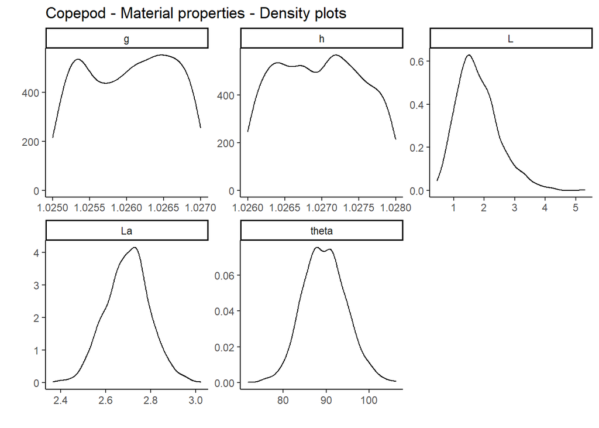

```r
######################################################################
#create a get_para funciton
get_para <- function(pm,spec,fn=-1){
#length distribution - this is made up...
if(spec=='krill'){
  pmsel = pm%>%filter(species=='Euphausiids1')
  L = c(abs(rnorm(9*nsim/10,3,3)), rnorm(1*nsim/10, 20,4))
  }else{
  pmsel = pm%>%filter(species==spec)
  L = rgamma(nsim,shape=pmsel$L_shape,rate=pmsel$L_rate)
  }
  cp = data.frame(species=spec,
  L=L,
  La=rnorm(nsim, pmsel$L_a_mean, pmsel$L_a_sd),
  g=runif(nsim, pmsel$g_min, pmsel$g_max),
  h=runif(nsim, pmsel$h_min, pmsel$h_max),
  taper=pmsel$taper,
  rhol=pmsel$rho_l,
  pf=fn,
  theta=rnorm(nsim, pmsel$theta_mean, pmsel$theta_sd))
  cdf = gather(cp,'var','value',-species,-taper, -rhol,-pf)
  subtit <- c('L' = "Length~(mm)",
  'La' = "L/a",
  'g' ="Density~contrast~g",
  'h' = 'Sound~speed~contrast~h',
  'theta' = 'Angle~theta~(degree)' )
  p <- ggplot(data=cdf, aes(x=value))+
  geom_density()+
  facet_wrap(.~var, scales='free')+#, labeller =labeller(var= as_labeller(subtit, label_parsed)))+
  theme_classic()+
  ggtitle(paste(spec,'- Material properties - Density plots'))+
  xlab('')+ylab('')
  return(list(cp,p))
}
##################################################################
#set copepod settings
#fn = paste0(system.file(package="ZooScatR"),"/extdata/profiles/copepod0.dat")
fn = 'cop0.sat'
cout = get_para(pm, 'Copepod', fn)
cdf = cout[[1]]
cout[[2]]
```

#### Krill (Euphausiacea furcilia)

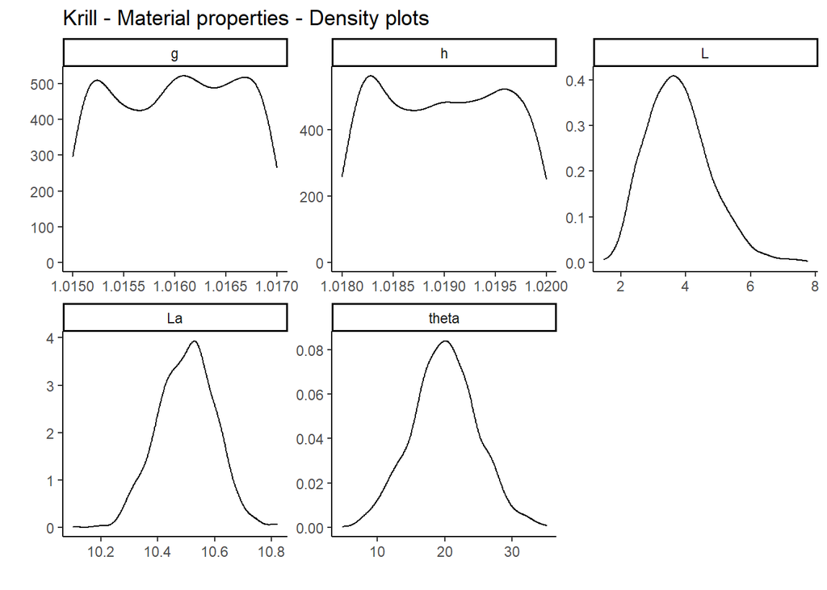

```r
fn = paste0(system.file(package="ZooScatR"),"/extdata/profiles/euphaus0.dat")
eout = get_para(pm, 'Krill',fn)
edf = eout[[1]]
eout[[2]]
```

#### Chaetognaths (Eukrohnia hamata)

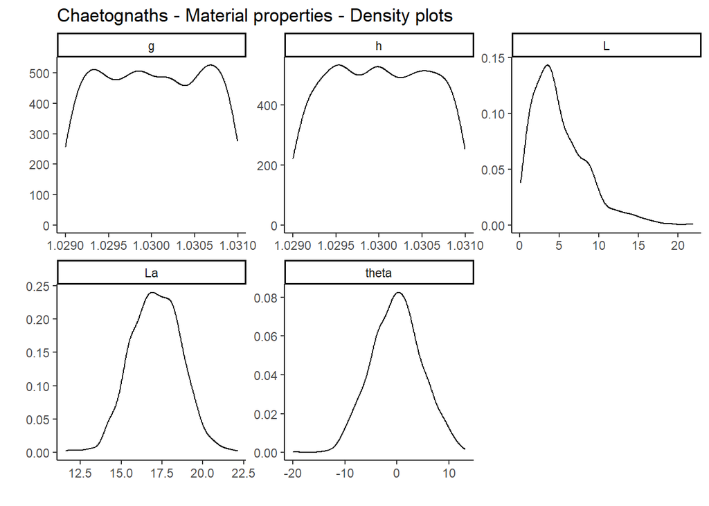

```r
fn = 'chaeto0.sat'
chout = get_para(pm, 'Chaetognaths',fn)
chdf = chout[[1]]
chout[[2]]
```

#### Krill Big (thyssanoessa inermis)

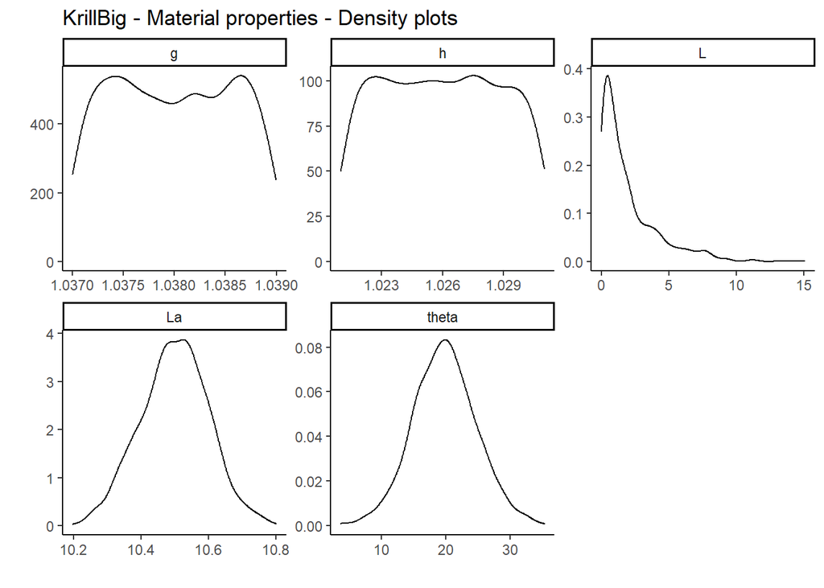

```r
fn = paste0(system.file(package="ZooScatR"),"/extdata/profiles/euphaus0.dat")
kbpout = get_para(pm, 'KrillBig',fn)
kbpdf = kbpout[[1]]
kbpout[[2]]
```

#### Amphipod (themisto abyssorum)

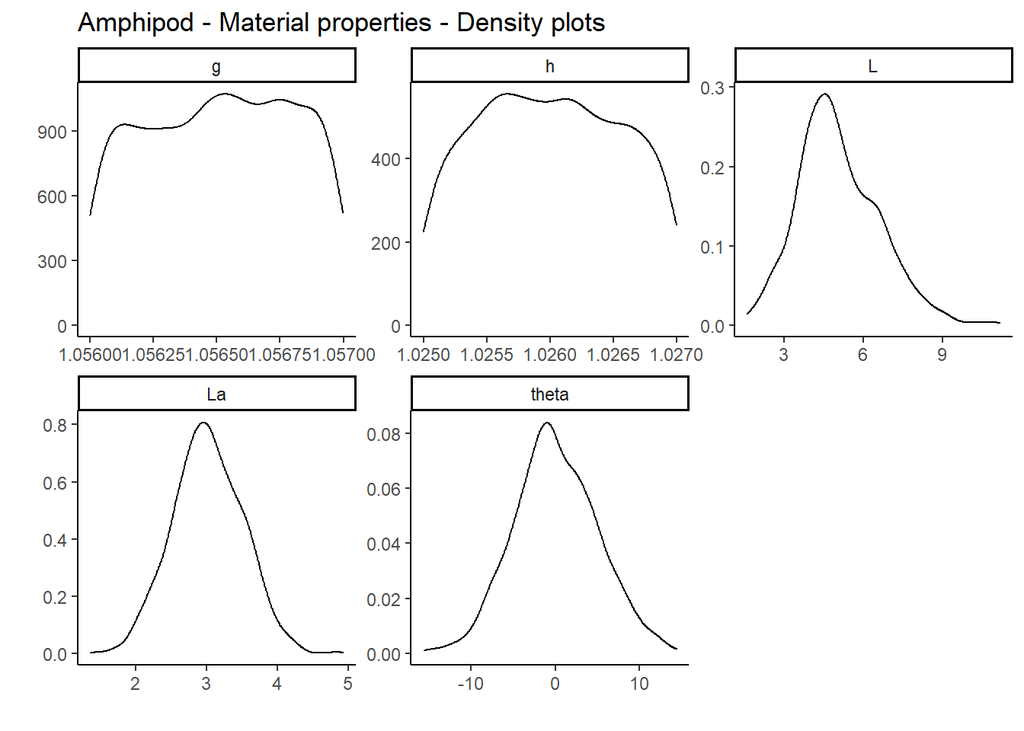

```r
fn = 'amphipod0.sat'
apout = get_para(pm, 'Amphipod',fn)
apdf = apout[[1]]
apout[[2]]
```

#### pteropod (limacina retroversa)

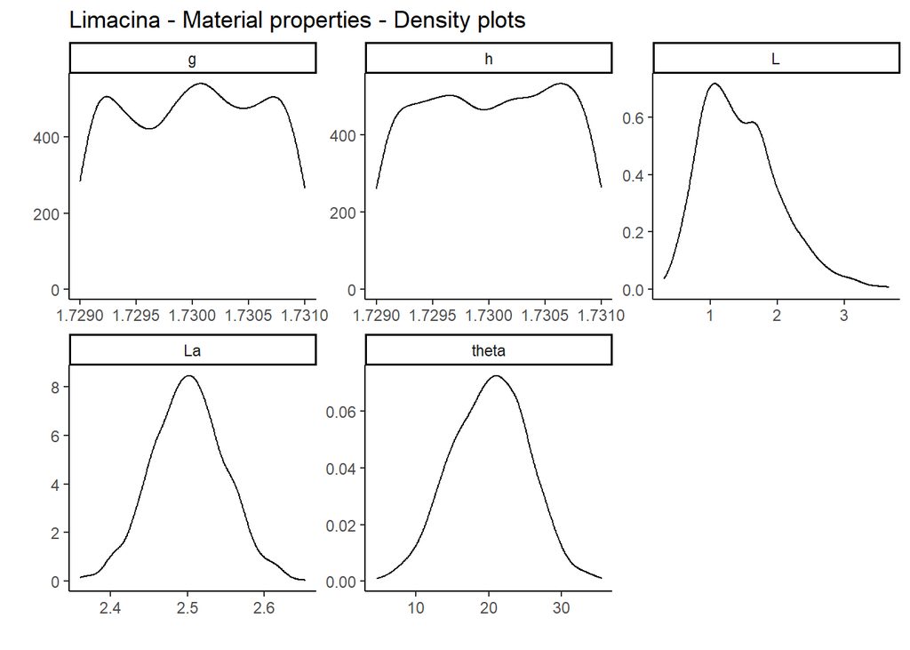

```r
fn = 'pteropod0.sat'
lpout = get_para(pm, 'Limacina',fn)
lpdf = lpout[[1]]
lpout[[2]]
```

#### fish larvae (cod larvae with swimbladder)

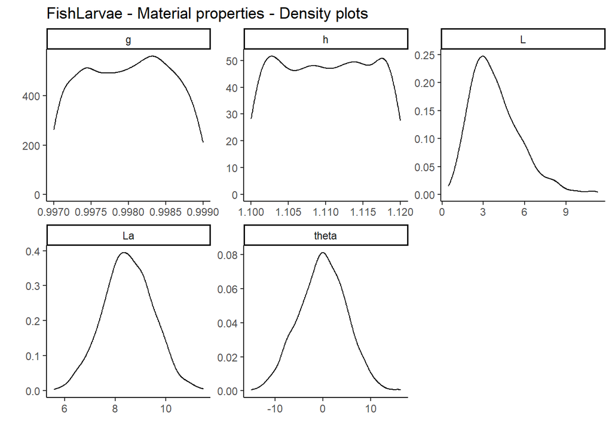

```r
fn = 'pteropod0.sat'
flpout = get_para(pm, 'FishLarvae',fn)
flpdf = flpout[[1]]
flpout[[2]]
```

### Run the model

Now we can combine all the settings and prepare to run the simulations:

```r
setdf = do.call('rbind',list(cdf,edf,chdf,kbpdf,apdf,lpdf,flpdf))
set_para <- function(i, shape=FALSE, setdf=setdf){
  para = ZooScatR::read_para(fname)
  #set the soundspeed in the surrounding sea water
  #misc <- list(cw=1500)
  #let's set the start and end frequencies
  para$simu$var0=f0
  para$simu$var1=f1
  #number of output frequencies
  para$simu$n=nf
  para$shape$L = setdf$L[i]
  para$shape$L_a = setdf$La[i]
  para$phy$g0 = setdf$g[i]
  para$phy$h0 = setdf$h[i]
  para$shape$order = setdf$taper[i]
  para$shape$rho_L = setdf$rhol[i]
  para$shape$prof_name = setdf$pf[i]
  para$orient$angm = setdf$theta[i]

  if(shape==FALSE){
    res = ZooScatR::bscat(para=para, misc=misc) #Target strength vs Frequency
    tmp=data.frame(TS=res$y,
    freq=seq(f0,f1, length.out = nf),
    L=para$shape$L,
    la=para$shape$L_a,
    g=para$phy$g0,
    h=para$phy$h0,
    orient=para$orient$angm,
    spec=setdf$species[i])
    return(tmp)

  }else{
    p = buildpos(para)
    p = p$plot
    p = p+coord_equal()
    p = p+ggtitle(setdf$species[i])
    print(p)
    return(p)
  }
}
```

### Model input shapes

First let’s have a look at the selected shapes:

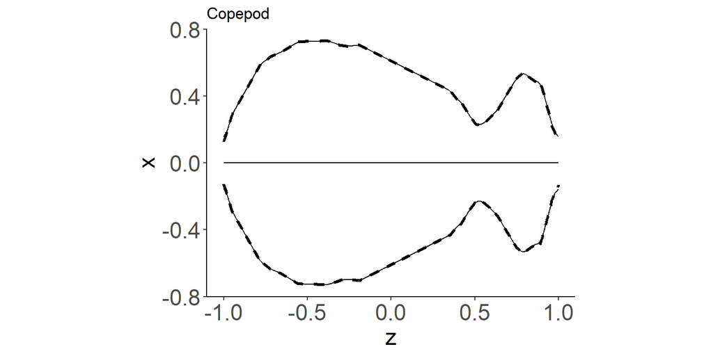

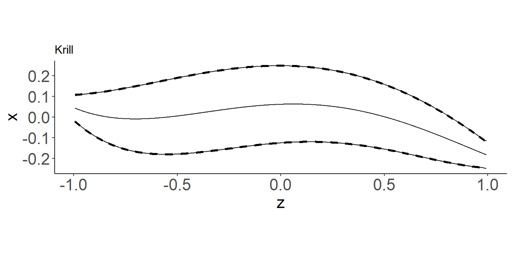

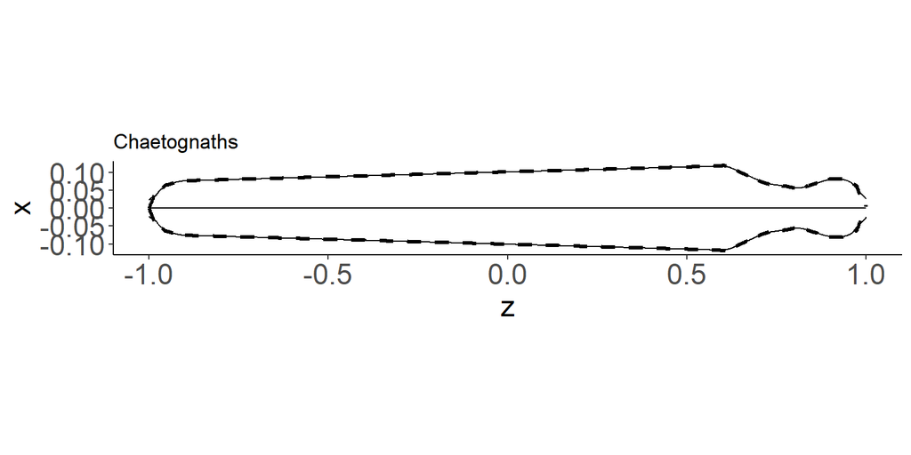

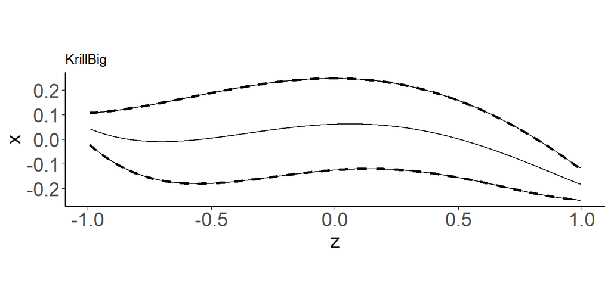

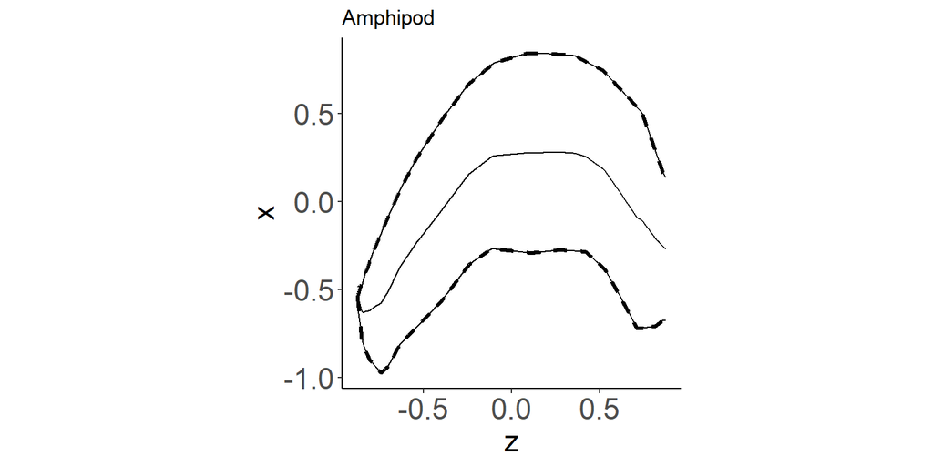

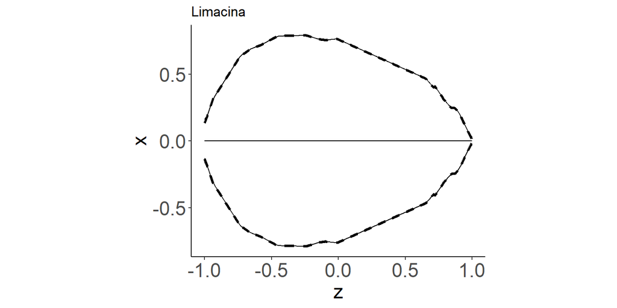

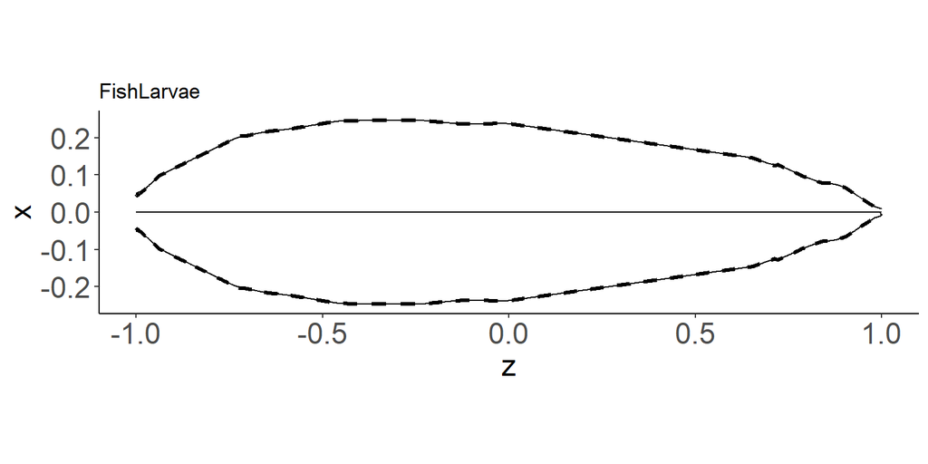

```r
specp = setdf%>%group_by(species)%>%filter(row_number()==1)
for(i in 1:length(specp$species)){set_para(i,shape=TRUE, setdf=specp)}
```

Now we can run the simulations:

```r
if(force ==FALSE & file.exists('sim2.RDS')){
  message(Sys.time(), ': Found simulations...Using old simulaitons...')
  sim = readRDS('sim2.RDS')
}else{
message(Sys.time(),': Running simulations...')
if(runParallel == TRUE){
sim = foreach(i=1:length(setdf$L), .combine=rbind) %dopar% {set_para(i, shape=FALSE,setdf=setdf)}
}else{
sim = do.call('rbind',
pbapply(matrix(1:length(setdf$L)),1,function(i){set_para(i, shape=FALSE,setdf=setdf)})
)
}
message(Sys.time(),': Running simulations completed!')
saveRDS(sim, file='sim2.RDS', compress=TRUE)
}
```

Let’s have a look at the results.

Let’s plot TS grouped by species vs Length:

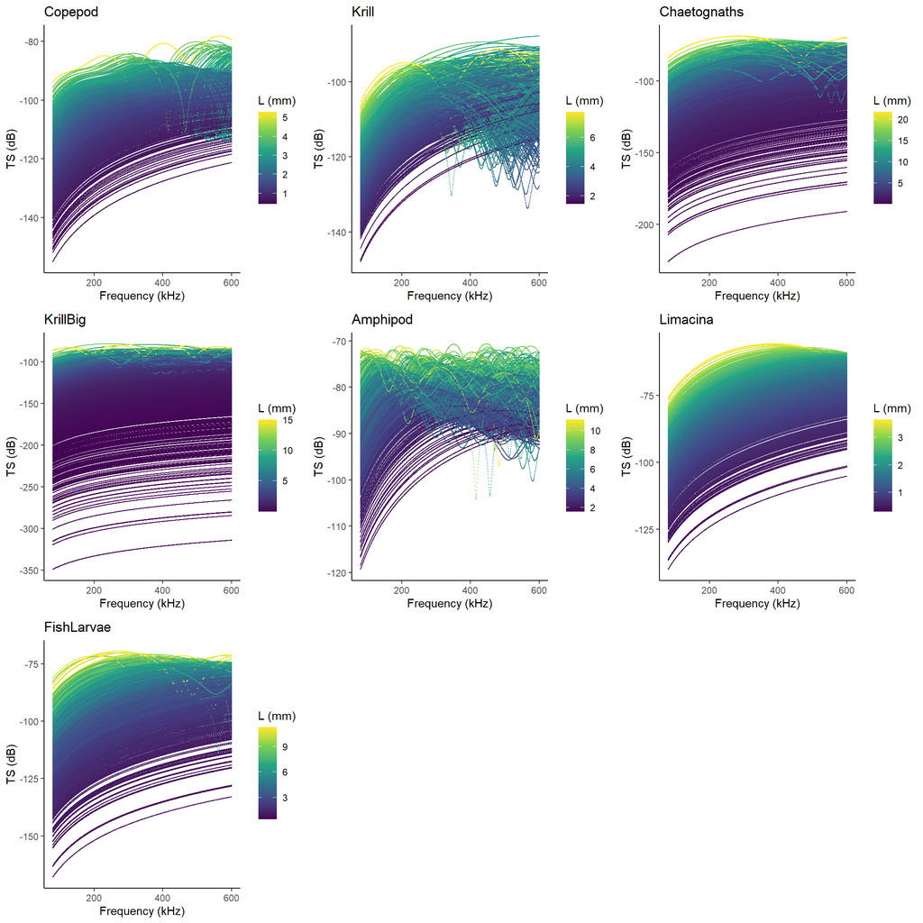

```r
plot_func <- function(sim, name='L (mm)', var='L', y='TS',x='freq', title) {
  ggplot(data = sim, aes_string(x = x, y = y, col = var)) +
    geom_point(size=0.01) +
    scale_colour_viridis_c(name=name)+
    ggtitle(title)+
    xlab('Frequency (kHz)')+
    ylab('TS (dB)')+
    theme_classic()
}
pL <- function(sim,spec){plot_func(sim, name='L (mm)', var='L', y='TS',x='freq', spec)}

sim_tmp <- sim %>%
  group_by(spec) %>%
  nest() %>%
  mutate(plots = map2(data, spec, pL))
pL = gridExtra::grid.arrange(grobs = sim_tmp$plots)
```

To have a look at the overall distribution, we can also look at 2D density plots:

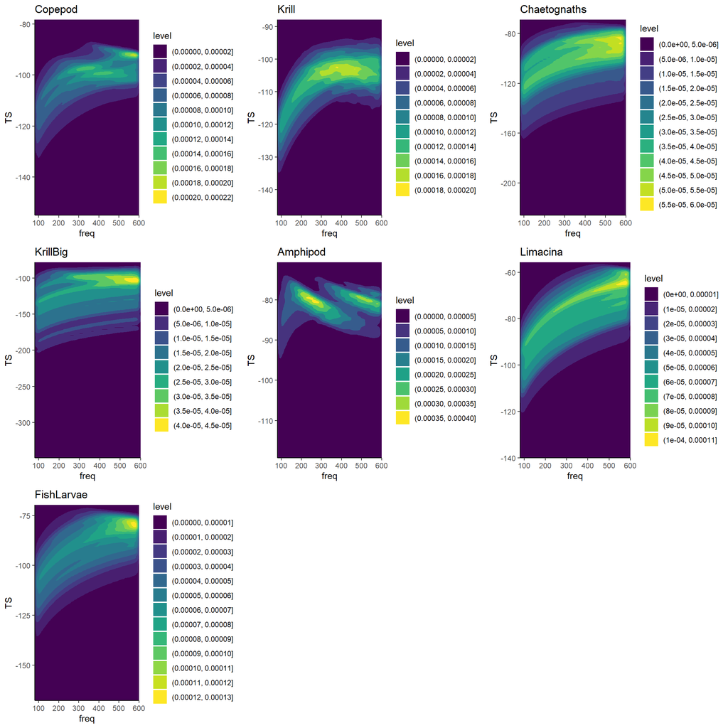

```r
pL <- function(sim, title){

  ggplot(data=sim, aes(x=freq, y=TS))+
    geom_density2d_filled()+
    #facet_wrap(.~spec, scales='free')+
    scale_x_continuous(expand=c(0,0))+
    scale_y_continuous(expand=c(0,0))+
    ggtitle(title)+
    theme_classic()
}


sim_tmp <- sim%>%
  group_by(spec) %>%
  nest() %>%
  mutate(plots = map2(data, spec, pL))
pL = gridExtra::grid.arrange(grobs = sim_tmp$plots)
```

```r
path <- "my_data_mean.feather"
write_feather(sim, path)
```